# Shashi_proj2_Supervised_Learning_Personal_Loan_Campaign_Modelling

## Thera Bank Personal Loan Campaign

### Data Description:

The dataset contains data on 5000 customers. The data include customer demographic information (age, income, etc.), the customer's relationship with the bank (mortgage, securities account, etc.), and the customer response to the last personal loan campaign (Personal Loan). Among these 5000 customers, only 480 (= 9.6%) accepted the personal loan that was offered to them in the earlier campaign.

### Domain:

Banking

### Context:

This case is about a bank (Thera Bank) whose management wants to explore ways of converting its liability customers to personal loan customers (while retaining them as depositors). A campaign that the bank ran last year for liability customers showed a healthy conversion rate of over 9% success. This has encouraged the retail marketing department to devise campaigns with better target marketing to increase the success ratio with a minimal budget.

### Attribute Information:

1. ID: Customer ID
2. Age: Customer's age in completed years
3. Experience: #years of professional experience
4. Income: Annual income of the customer
5. ZIP Code: Home Address ZIP code.
6. Family: Family size of the customer
7. CCAvg: Avg. spending on credit cards per month
8. Education: Education Level. 1: Undergrad; 2: Graduate; 3: Advanced/Professional
9. Mortgage: Value of house mortgage if any.
10. Personal Loan: Did this customer accept the personal loan offered in the last campaign?
11. Securities Account: Does the customer have a securities account with the bank?
12. CD Account: Does the customer have a certificate of deposit (CD) account with the bank?
13. Online: Does the customer use internet banking facilities?
14. Credit card: Does the customer use a credit card issued by the bank?

## 1 Import Libraries

Import the datasets and libraries, check datatype, statistical summary, shape, null values or incorrect imputation.

```python
import warnings
warnings.filterwarnings('ignore')
```

```python
#Load Libraries
import numpy as np # linear algebra
import pandas as pd # data processing, CSV file I/O (e.g. pd.read_csv)
import matplotlib.pyplot as plt       # matplotlib.pyplot plots data
%matplotlib inline
import seaborn as sns
```

## 1 Load and review data

```python
pdata = pd.read_csv("Bank_Personal_Loan_Modelling.csv")
```

```python
pdata.shape # Check number of columns and rows in data frame (shape)
```

```
(5000, 14)
```

```python
pdata.head() # To check first 5 rows of data set
```

|  | ID | Age | Experience | Income | ZIP Code | Family | CCAvg | Education | Mortgage | Personal Loan | Securities Account | CD Account | Online | CreditCard |
| --- | --- | --- | --- | --- | --- | --- | --- | --- | --- | --- | --- | --- | --- | --- |
| 0 | 1 | 25 | 1 | 49 | 91107 | 4 | 1.6 | 1 | 0 | 0 | 1 | 0 | 0 | 0 |
| 1 | 2 | 45 | 19 | 34 | 90089 | 3 | 1.5 | 1 | 0 | 0 | 1 | 0 | 0 | 0 |
| 2 | 3 | 39 | 15 | 11 | 94720 | 1 | 1.0 | 1 | 0 | 0 | 0 | 0 | 0 | 0 |
| 3 | 4 | 35 | 9 | 100 | 94112 | 1 | 2.7 | 2 | 0 | 0 | 0 | 0 | 0 | 0 |
| 4 | 5 | 35 | 8 | 45 | 91330 | 4 | 1.0 | 2 | 0 | 0 | 0 | 0 | 0 | 1 |

```python
pdata.tail() # To check last 5 rows of data set
```

|  | ID | Age | Experience | Income | ZIP Code | Family | CCAvg | Education | Mortgage | Personal Loan | Securities Account | CD Account | Online | CreditCard |
| --- | --- | --- | --- | --- | --- | --- | --- | --- | --- | --- | --- | --- | --- | --- |
| 4995 | 4996 | 29 | 3 | 40 | 92697 | 1 | 1.9 | 3 | 0 | 0 | 0 | 0 | 1 | 0 |
| 4996 | 4997 | 30 | 4 | 15 | 92037 | 4 | 0.4 | 1 | 85 | 0 | 0 | 0 | 1 | 0 |
| 4997 | 4998 | 63 | 39 | 24 | 93023 | 2 | 0.3 | 3 | 0 | 0 | 0 | 0 | 0 | 0 |
| 4998 | 4999 | 65 | 40 | 49 | 90034 | 3 | 0.5 | 2 | 0 | 0 | 0 | 0 | 1 | 0 |
| 4999 | 5000 | 28 | 4 | 83 | 92612 | 3 | 0.8 | 1 | 0 | 0 | 0 | 0 | 1 | 1 |

```python
pdata.isnull().values.any() # If there are any null values in data set
```

```
False
```

```python
pdata.isnull().sum()
```

```
ID                    0
Age                   0
Experience            0
Income                0
ZIP Code              0
Family                0
CCAvg                 0
Education             0
Mortgage              0
Personal Loan         0
Securities Account    0
CD Account            0
Online                0
CreditCard            0
dtype: int64
```

```python
columns = list(pdata)[0:14]
print(columns)
```

```
['ID', 'Age', 'Experience', 'Income', 'ZIP Code', 'Family', 'CCAvg', 'Education', 'Mortgage', 'Personal Loan', 'Securities Account', 'CD Account', 'Online', 'CreditCard']
```

```python
pdata[columns].dtypes # Data Types of the coloumns
```

```
ID                      int64
Age                     int64
Experience              int64
Income                  int64
ZIP Code                int64
Family                  int64
CCAvg                 float64
Education               int64
Mortgage                int64
Personal Loan           int64
Securities Account      int64
CD Account              int64
Online                  int64
CreditCard              int64
dtype: object
```

```python
pdata.info() # Data Types of the coloumns and null values in data set
```

```
<class 'pandas.core.frame.DataFrame'>
RangeIndex: 5000 entries, 0 to 4999
Data columns (total 14 columns):
 #   Column              Non-Null Count  Dtype
---  ------              --------------  -----
 0   ID                  5000 non-null   int64
 1   Age                 5000 non-null   int64
 2   Experience          5000 non-null   int64
 3   Income              5000 non-null   int64
 4   ZIP Code            5000 non-null   int64
 5   Family              5000 non-null   int64
 6   CCAvg               5000 non-null   float64
 7   Education           5000 non-null   int64
 8   Mortgage            5000 non-null   int64
 9   Personal Loan       5000 non-null   int64
 10  Securities Account  5000 non-null   int64
 11  CD Account          5000 non-null   int64
 12  Online              5000 non-null   int64
 13  CreditCard          5000 non-null   int64
dtypes: float64(1), int64(13)
memory usage: 547.0 KB
```

```python
pdata[columns].describe() # Summary statistics (mean, standard deviation, min, max, Q1, Q2, Q3)
```

|  | ID | Age | Experience | Income | ZIP Code | Family | CCAvg | Education | Mortgage | Personal Loan | Securities Account | CD Account | Online | CreditCard |
| --- | --- | --- | --- | --- | --- | --- | --- | --- | --- | --- | --- | --- | --- | --- |
| count | 5000.000000 | 5000.000000 | 5000.000000 | 5000.000000 | 5000.000000 | 5000.000000 | 5000.000000 | 5000.000000 | 5000.000000 | 5000.000000 | 5000.000000 | 5000.00000 | 5000.000000 | 5000.000000 |
| mean | 2500.500000 | 45.338400 | 20.104600 | 73.774200 | 93152.503000 | 2.396400 | 1.937938 | 1.881000 | 56.498800 | 0.096000 | 0.104400 | 0.06040 | 0.596800 | 0.294000 |
| std | 1443.520003 | 11.463166 | 11.467954 | 46.033729 | 2121.852197 | 1.147663 | 1.747659 | 0.839869 | 101.713802 | 0.294621 | 0.305809 | 0.23825 | 0.490589 | 0.455637 |
| min | 1.000000 | 23.000000 | -3.000000 | 8.000000 | 9307.000000 | 1.000000 | 0.000000 | 1.000000 | 0.000000 | 0.000000 | 0.000000 | 0.00000 | 0.000000 | 0.000000 |
| 25% | 1250.750000 | 35.000000 | 10.000000 | 39.000000 | 91911.000000 | 1.000000 | 0.700000 | 1.000000 | 0.000000 | 0.000000 | 0.000000 | 0.00000 | 0.000000 | 0.000000 |
| 50% | 2500.500000 | 45.000000 | 20.000000 | 64.000000 | 93437.000000 | 2.000000 | 1.500000 | 2.000000 | 0.000000 | 0.000000 | 0.000000 | 0.00000 | 1.000000 | 0.000000 |
| 75% | 3750.250000 | 55.000000 | 30.000000 | 98.000000 | 94608.000000 | 3.000000 | 2.500000 | 3.000000 | 101.000000 | 0.000000 | 0.000000 | 0.00000 | 1.000000 | 1.000000 |
| max | 5000.000000 | 67.000000 | 43.000000 | 224.000000 | 96651.000000 | 4.000000 | 10.000000 | 3.000000 | 635.000000 | 1.000000 | 1.000000 | 1.00000 | 1.000000 | 1.000000 |

```python
pdata[columns].median() # Median
```

```
ID                     2500.5
Age                      45.0
Experience               20.0
Income                   64.0
ZIP Code              93437.0
Family                    2.0
CCAvg                     1.5
Education                 2.0
Mortgage                  0.0
Personal Loan             0.0
Securities Account        0.0
CD Account                0.0
Online                    1.0
CreditCard                0.0
dtype: float64
```

```python
pdata[columns].skew() #Skew
```

```
ID                     0.000000
Age                   -0.029341
Experience            -0.026325
Income                 0.841339
ZIP Code             -12.500221
Family                 0.155221
CCAvg                  1.598443
Education              0.227093
Mortgage               2.104002
Personal Loan          2.743607
Securities Account     2.588268
CD Account             3.691714
Online                -0.394785
CreditCard             0.904589
dtype: float64
```

## 2 EDA: Study the data distribution in each attribute and target variable, share your findings

```python
pdata[columns].nunique() # Number of unique in each column
```

```
ID                    5000
Age                     45
Experience              47
Income                 162
ZIP Code               467
Family                   4
CCAvg                  108
Education                3
Mortgage               347
Personal Loan            2
Securities Account       2
CD Account               2
Online                   2
CreditCard               2
dtype: int64
```

```python
pdata[columns].count() # Count only non null values
```

```
ID                    5000
Age                   5000
Experience            5000
Income                5000
ZIP Code              5000
Family                5000
CCAvg                 5000
Education             5000
Mortgage              5000
Personal Loan         5000
Securities Account    5000
CD Account            5000
Online                5000
CreditCard            5000
dtype: int64
```

```python
pdata[columns].agg(['count', 'size', 'nunique'])
```

|  | ID | Age | Experience | Income | ZIP Code | Family | CCAvg | Education | Mortgage | Personal Loan | Securities Account | CD Account | Online | CreditCard |
| --- | --- | --- | --- | --- | --- | --- | --- | --- | --- | --- | --- | --- | --- | --- |
| count | 5000 | 5000 | 5000 | 5000 | 5000 | 5000 | 5000 | 5000 | 5000 | 5000 | 5000 | 5000 | 5000 | 5000 |
| size | 5000 | 5000 | 5000 | 5000 | 5000 | 5000 | 5000 | 5000 | 5000 | 5000 | 5000 | 5000 | 5000 | 5000 |
| nunique | 5000 | 45 | 47 | 162 | 467 | 4 | 108 | 3 | 347 | 2 | 2 | 2 | 2 | 2 |

```python
(pdata['Mortgage'] == 0).sum() #Number of people with zero mortgage?
```

```
3462
```

```python
#Number of people with zero credit card spending per month?
(pdata['CCAvg'] == 0).sum()
```

```
106
```

```python
# frequency or Value counts of all categorical columns
count_e = pdata['Education'].value_counts()
count_p = pdata['Personal Loan'].value_counts()
count_s = pdata['Securities Account'].value_counts()
count_c = pdata['CD Account'].value_counts()
count_o = pdata['Online'].value_counts()
print(count_e)
print("\n")
print(count_p)
print("\n")
print(count_s)
print("\n")
print(count_c)
print("\n")
print(count_o)
```

```
1    2096
3    1501
2    1403
Name: Education, dtype: int64


0    4520
1     480
Name: Personal Loan, dtype: int64


0    4478
1     522
Name: Securities Account, dtype: int64


0    4698
1     302
Name: CD Account, dtype: int64


1    2984
0    2016
Name: Online, dtype: int64
```

```python
count_f = pdata['Family'].value_counts() # Family size is not Categorical. It is discreate value. Just showed here for analysis
print(count_f)
```

```
1    1472
2    1296
4    1222
3    1010
Name: Family, dtype: int64
```

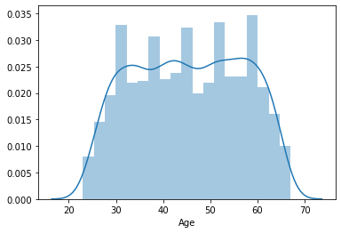

```python
#Univariate
age = pdata['Age']
sns.distplot(age)
```

The distribution of Age does not have a skew. Mean and median are close together.

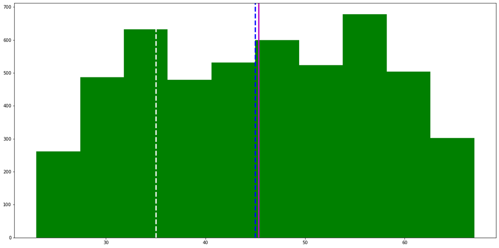

```python
plt.figure(figsize=(20,10)) # makes the plot wider
plt.hist(age, color='g') # plots a simple histogram
plt.axvline(age.mean(), color='m', linewidth=3)
plt.axvline(age.median(), color='b', linestyle='dashed', linewidth=3)
plt.axvline(age.mode()[0], color='w', linestyle='dashed', linewidth=3)
```

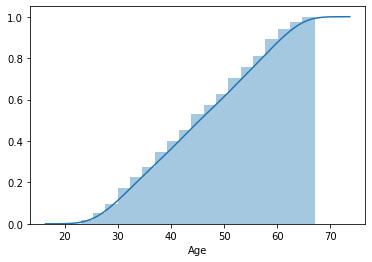

```python
sns.distplot(age, hist_kws=dict(cumulative=True), kde_kws=dict(cumulative=True)) #Cumulative Distribution
```

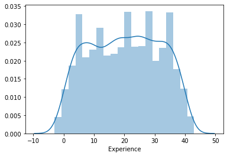

```python
experience = pdata['Experience']
sns.distplot(experience)
```

The distribution of Experience does not have a skew. Mean and median are close together.

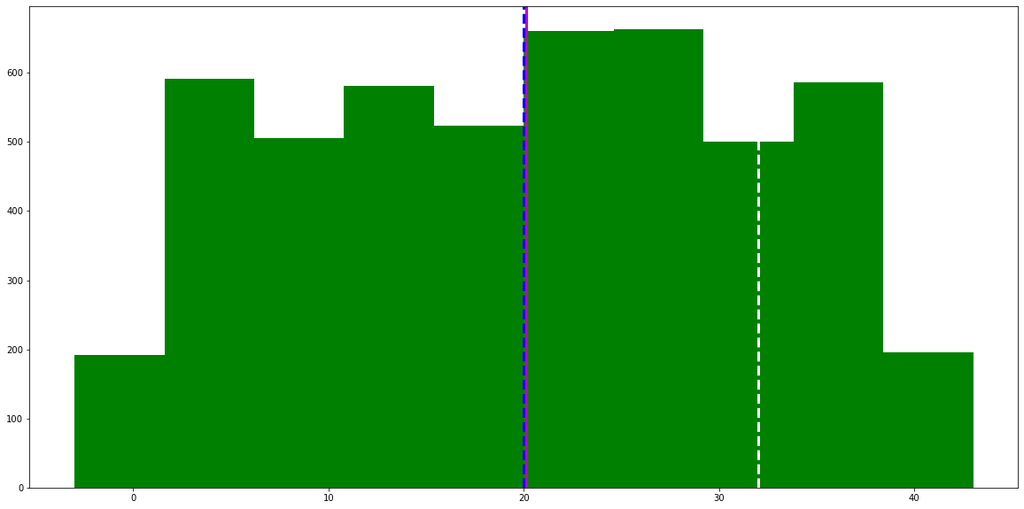

```python
plt.figure(figsize=(20,10)) # makes the plot wider
plt.hist(experience, color='g') # plots a simple histogram
plt.axvline(experience.mean(), color='m', linewidth=3)
plt.axvline(experience.median(), color='b', linestyle='dashed', linewidth=3)
plt.axvline(experience.mode()[0], color='w', linestyle='dashed', linewidth=3)
```

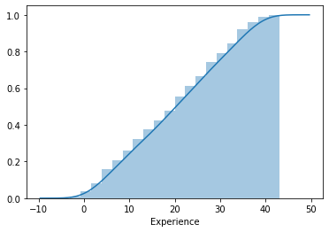

```python
sns.distplot(experience, hist_kws=dict(cumulative=True), kde_kws=dict(cumulative=True)) #Cumulative Distribution
```

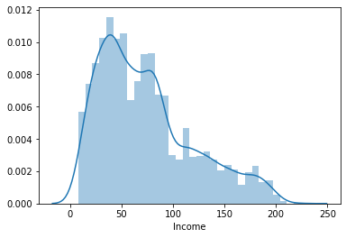

```python
income = pdata['Income']
sns.distplot(income)
```

The distribution of Income has a positive skew.

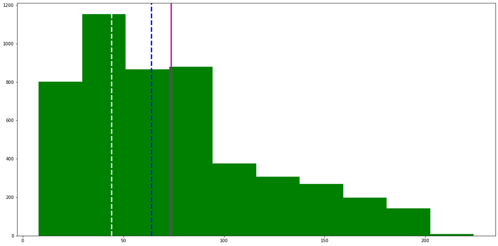

```python
plt.figure(figsize=(20,10)) # makes the plot wider
plt.hist(income, color='g') # plots a simple histogram
plt.axvline(income.mean(), color='m', linewidth=3)
plt.axvline(income.median(), color='b', linestyle='dashed', linewidth=3)
plt.axvline(income.mode()[0], color='w', linestyle='dashed', linewidth=3)
```

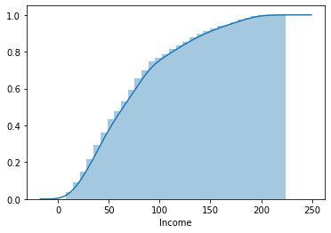

```python
sns.distplot(income, hist_kws=dict(cumulative=True), kde_kws=dict(cumulative=True)) #Cumulative Distribution
```

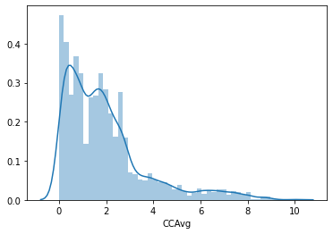

```python
ccavg = pdata['CCAvg']
sns.distplot(ccavg)
```

The distribution of Credit Card Avg has a positive skew.

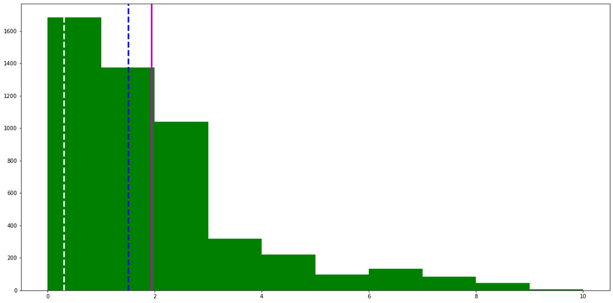

```python
plt.figure(figsize=(20,10)) # makes the plot wider
plt.hist(ccavg, color='g') # plots a simple histogram
plt.axvline(ccavg.mean(), color='m', linewidth=3)
plt.axvline(ccavg.median(), color='b', linestyle='dashed', linewidth=3)
plt.axvline(ccavg.mode()[0], color='w', linestyle='dashed', linewidth=3)
```

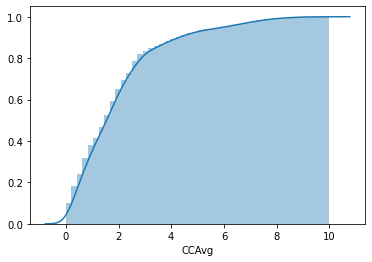

```python
sns.distplot(ccavg, hist_kws=dict(cumulative=True), kde_kws=dict(cumulative=True)) #Cumulative Distribution
```

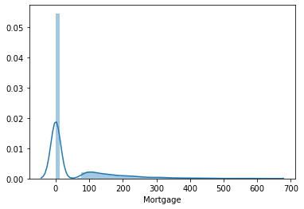

```python
mortgage = pdata['Mortgage']
sns.distplot(mortgage)
```

A lot of customers have a zero mortage amount.

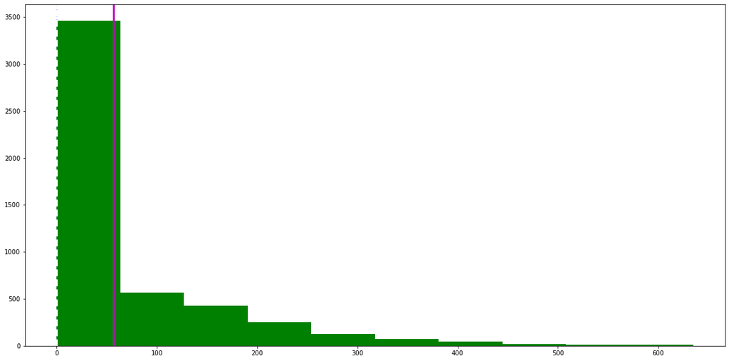

```python
plt.figure(figsize=(20,10)) # makes the plot wider
plt.hist(mortgage, color='g') # plots a simple histogram
plt.axvline(mortgage.mean(), color='m', linewidth=3)
plt.axvline(mortgage.median(), color='b', linestyle='dashed', linewidth=3)
plt.axvline(mortgage.mode()[0], color='w', linestyle='dashed', linewidth=3)
```

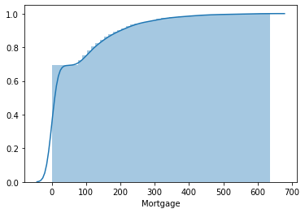

```python
sns.distplot(mortgage, hist_kws=dict(cumulative=True), kde_kws=dict(cumulative=True)) #Cumulative Distribution
```

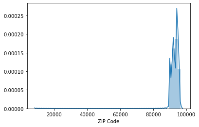

```python
zipcode = pdata['ZIP Code']
sns.distplot(zipcode)
```

A lot of customers seems to be residing in a cluster of zipcodes.

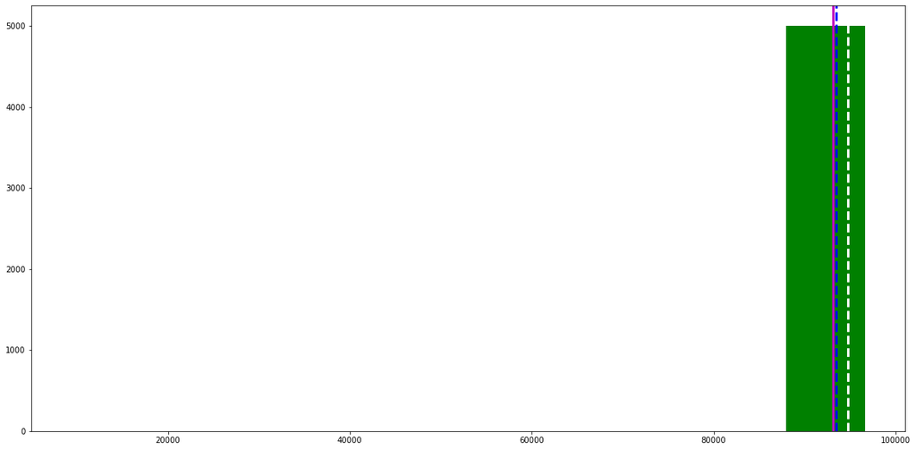

```python
plt.figure(figsize=(20,10)) # makes the plot wider
plt.hist(zipcode, color='g') # plots a simple histogram
plt.axvline(zipcode.mean(), color='m', linewidth=3)
plt.axvline(zipcode.median(), color='b', linestyle='dashed', linewidth=3)
plt.axvline(zipcode.mode()[0], color='w', linestyle='dashed', linewidth=3)
```

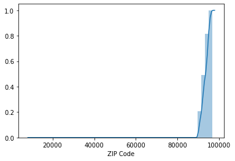

```python
sns.distplot(zipcode, hist_kws=dict(cumulative=True), kde_kws=dict(cumulative=True)) #Cumulative Distribution
```

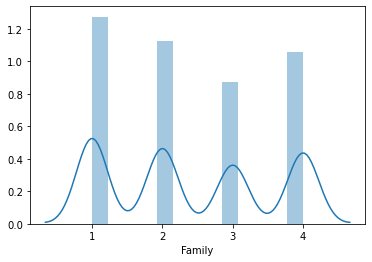

```python
family = pdata['Family']
sns.distplot(family)
```

Family size is discreate. There are more single people.

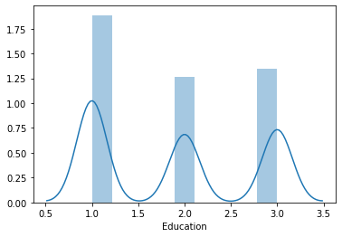

```python
education = pdata['Education'] #This shows that this is a categorical Variable.
sns.distplot(education)
```

Education is a categorical Variable.

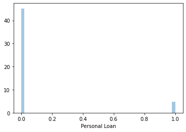

```python
personalloan = pdata['Personal Loan'] #This shows that this is a categorical Variable.
sns.distplot(personalloan)
```

The target variable (Personal Loan) is a categorical Variable.

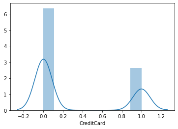

```python
creditcard = pdata['CreditCard'] #This shows that this is a categorical Variable.
sns.distplot(creditcard)
```

CreditCard is a categorical Variable.

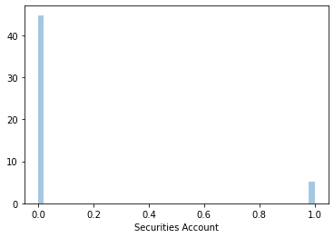

```python
securitiesaccount = pdata['Securities Account'] #This shows that this is a categorical Variable.
sns.distplot(securitiesaccount)
```

Securities Account is a categorical Variable.

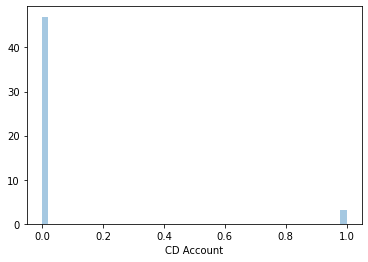

```python
cdaccount = pdata['CD Account'] #This shows that this is a categorical Variable.
sns.distplot(cdaccount)
```

CD Account is a categorical Variable.

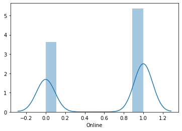

```python
online = pdata['Online'] #This shows that this is a categorical Variable.
sns.distplot(online)
```

Online is a categorical Variable.

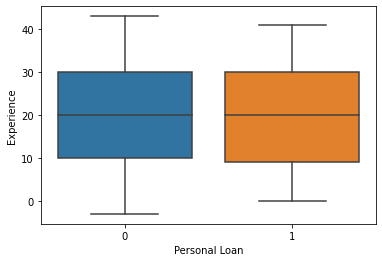

```python
#Bivariate Analysis

sns.boxplot(data=pdata,x='Personal Loan',y='Experience')
plt.show()
```

There distrubution is even among experienced people that have opted for the loan and not opted for the personal loan.